# cost_of_living_project

Cost of Living Index 2024 Data from Kaggle  
[https://www.kaggle.com/datasets/myrios/cost-of-living-index-by-country-by-number-2024/data\](https://www.kaggle.com/datasets/myrios/cost-of-living-index-by-country-by-number-2024/data%5C) About Dataset

Cost of Living Index by Country, 2024 Mid Year data Data scraped from Numbeo: www.numbeo.com/cost-of-living/rankings_by_country.jsp All credits to Numbeo: www.numbeo.com/cost-of-living/

An index of 100 reflects the same living cost as in New York City, United States. As of 2024 Mid Year data, in NYC, A family of four estimated monthly costs are $6,074.40 without rent. A single person's estimated monthly costs are $1,640.90 without rent.

The cost of living index is relative to New York City. So, a cost of living index of 101.1 for Switzerland is equivalent to 1.1% higher cost of living compared to New York City.  
Source: https://www.numbeo.com/cost-of-living/cpi_explained.jsp  
https://www.numbeo.com/common/motivation_and_methodology.jsp

```python
import pandas as pd
import seaborn as sns
import plotly.express as px
import matplotlib.pyplot as plt
import plotly.io as pio
pio.renderers.default = 'notebook'
```

```python
df = pd.read_csv('archive(1)/Cost_of_Living_Index_by_Country_2024.csv')
```

```python
df.head()
```

|  | Rank | Country | Cost of Living Index | Rent Index | Cost of Living Plus Rent Index | Groceries Index | Restaurant Price Index | Local Purchasing Power Index |
| --- | --- | --- | --- | --- | --- | --- | --- | --- |
| 0 | 1 | Switzerland | 101.1 | 46.5 | 74.9 | 109.1 | 97.0 | 158.7 |
| 1 | 2 | Bahamas | 85.0 | 36.7 | 61.8 | 81.6 | 83.3 | 54.6 |
| 2 | 3 | Iceland | 83.0 | 39.2 | 62.0 | 88.4 | 86.8 | 120.3 |
| 3 | 4 | Singapore | 76.7 | 67.2 | 72.1 | 74.6 | 50.4 | 111.1 |
| 4 | 5 | Barbados | 76.6 | 19.0 | 48.9 | 80.8 | 69.4 | 43.5 |

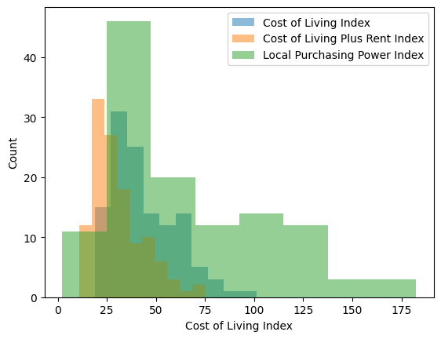

```python
cols = ['Cost of Living Index', 'Cost of Living Plus Rent Index', 'Local Purchasing Power Index']
cols2 = df.iloc[:, 2:]
fig, ax = plt.subplots()
for a in cols:
    sns.histplot(df, x=a, ax=ax, kde=False, alpha=0.5, ec=None)
plt.legend(cols)
```

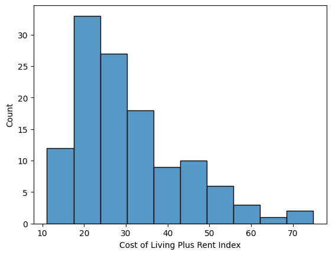

```python
sns.histplot(df, x='Cost of Living Plus Rent Index')
```

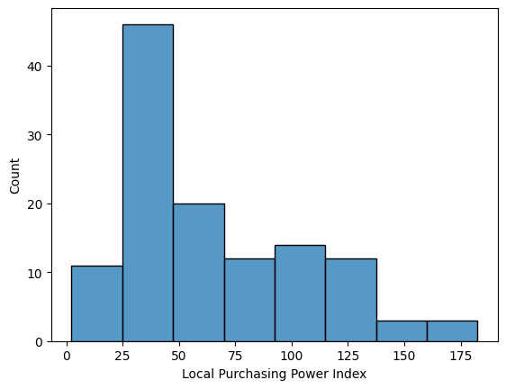

```python
sns.histplot(df, x='Local Purchasing Power Index')
```

```python
px.histogram(df, x=['Cost of Living Index',
                    'Cost of Living Plus Rent Index',
                    'Local Purchasing Power Index'],
                    opacity=0.75,
                    barmode='overlay',
                    hover_data='Country')
```

[output not shown]

Most countries have lower cost of living including rent or not including rent compared to New York City.

```python
#categorizing the countries into continents
continents = {

    'Switzerland': 'Europe',
    'Iceland': 'Europe',
    'Norway': 'Europe',
    'Denmark': 'Europe',
    'Austria': 'Europe',
    'Ireland': 'Europe',
    'France': 'Europe',
    'Finland': 'Europe',
    'Netherlands': 'Europe',
    'Luxembourg': 'Europe',
    'Germany': 'Europe',
    'United Kingdom': 'Europe',
    'Belgium': 'Europe',
    'Sweden': 'Europe',
    'Italy': 'Europe',
    'Cyprus': 'Europe',
    'Malta': 'Europe',
    'Greece': 'Europe',
    'Estonia': 'Europe',
    'Slovenia': 'Europe',
    'Latvia': 'Europe',
    'Spain': 'Europe',
    'Lithuania': 'Europe',
    'Slovakia': 'Europe',
    'Czech Republic': 'Europe',
    'Croatia': 'Europe',
    'Portugal': 'Europe',
    'Albania': 'Europe',
    'Hungary': 'Europe',
    'Poland': 'Europe',
    'Montenegro': 'Europe',
    'Bulgaria': 'Europe',
    'Serbia': 'Europe',
    'Romania': 'Europe',
    'Turkey': 'Europe',
    'Bosnia And Herzegovina': 'Europe',
    'Moldova': 'Europe',
    'Georgia': 'Europe',
    'North Macedonia': 'Europe',
    'Kosovo (Disputed Territory)': 'Europe',
    'Belarus': 'Europe',
    'Ukraine': 'Europe',

    'Israel': 'Middle East',
    'United Arab Emirates': 'Middle East',
    'Bahrain': 'Middle East',
    'Qatar': 'Middle East',
    'Saudi Arabia': 'Middle East',
    'Oman': 'Middle East',
    'Kuwait': 'Middle East',
    'Lebanon': 'Middle East',
    'Palestine': 'Middle East',
    'Jordan': 'Middle East',
    'Armenia': 'Middle East',
    'Azerbaijan': 'Middle East',
    'Iraq': 'Middle East',
    'Iran': 'Middle East',
    'Syria': 'Middle East',

    'Bahamas': 'North America',
    'Barbados': 'North America',
    'United States': 'North America',
    'Canada': 'North America',
    'Puerto Rico': 'North America',
    'Jamaica': 'North America',
    'Trinidad And Tobago': 'North America',
    'Costa Rica': 'North America',
    'Cuba': 'North America',
    'Panama': 'North America',
    'Mexico': 'North America',
    'Guatemala': 'North America',
    'Dominican Republic': 'North America',

    'Uruguay': 'South America',
    'El Salvador': 'South America',
    'Chile': 'South America',
    'Venezuela': 'South America',
    'Ecuador': 'South America',
    'Brazil': 'South America',
    'Peru': 'South America',
    'Argentina': 'South America',
    'Colombia': 'South America',
    'Bolivia': 'South America',
    'Paraguay': 'South America',

    'Singapore': 'Asia',
    'Hong Kong (China)': 'Asia',
    'South Korea': 'Asia',
    'Japan': 'Asia',
    'Taiwan': 'Asia',
    'Cambodia': 'Asia',
    'Sri Lanka': 'Asia',
    'Thailand': 'Asia',
    'Kazakhstan': 'Asia',
    'China': 'Asia',
    'Philippines': 'Asia',
    'Russia': 'Asia',
    'Malaysia': 'Asia',
    'Vietnam': 'Asia',
    'Kyrgyzstan': 'Asia',
    'Indonesia': 'Asia',
    'Uzbekistan': 'Asia',
    'Nepal': 'Asia',
    'Bangladesh': 'Asia',
    'India': 'Asia',
    'Pakistan': 'Asia',

    'Cameroon': 'Africa',
    'Zimbabwe': 'Africa',
    'Mauritius': 'Africa',
    'South Africa': 'Africa',
    'Nigeria': 'Africa',
    'Ghana': 'Africa',
    'Kenya': 'Africa',
    'Botswana': 'Africa',
    'Morocco': 'Africa',
    'Uganda': 'Africa',
    'Algeria': 'Africa',
    'Tunisia': 'Africa',
    'Madagascar': 'Africa',
    'Tanzania': 'Africa',
    'Egypt': 'Africa',
    'Libya': 'Africa',

    'Australia': 'Oceania',
    'New Zealand': 'Oceania',
    'Fiji': 'Oceania'

}
```

```python
continents_color = {
    'Europe': 'red',
    'Middle East': 'blue',
    'North America': 'green',
    'South America': 'purple',
    'Asia': 'turquoise',
    'Africa': 'gold',
    'Oceania': 'pink'
}
```

```python
df['Continent'] = df['Country'].map(continents)
```

```python
df.tail()
```

|  | Rank | Country | Cost of Living Index | Rent Index | Cost of Living Plus Rent Index | Groceries Index | Restaurant Price Index | Local Purchasing Power Index | Continent |
| --- | --- | --- | --- | --- | --- | --- | --- | --- | --- |
| 116 | 117 | Bangladesh | 22.5 | 2.4 | 12.8 | 25.7 | 12.8 | 33.1 | Asia |
| 117 | 118 | India | 21.2 | 5.6 | 13.7 | 23.8 | 15.1 | 82.6 | Asia |
| 118 | 119 | Egypt | 21.0 | 3.7 | 12.7 | 21.2 | 16.2 | 20.0 | Africa |
| 119 | 120 | Libya | 20.4 | 4.3 | 12.7 | 22.2 | 15.2 | 42.0 | Africa |
| 120 | 121 | Pakistan | 18.8 | 2.8 | 11.1 | 17.5 | 12.9 | 29.1 | Asia |

```python
px.scatter(df, x='Cost of Living Index',
           y='Local Purchasing Power Index',
           color='Continent',
           range_x=(0,200),
           range_y=(0,200),
           hover_name='Country',
           title='Local Purchasing Power Index by Cost of Living Index')
```

[output not shown]

```python
px.scatter(df, x='Cost of Living Plus Rent Index',
           y='Local Purchasing Power Index',
           color='Continent',
           range_x=(0,200),
           range_y=(0,200),
           hover_name='Country',
           title='Local Purchasing Power Index vs Cost of Living Plus Rent Index')
```

[output not shown]

```python
px.scatter(df, x='Groceries Index',
           y='Restaurant Price Index',
           color='Continent',
           range_x=(0,150),
           range_y=(0,150),
           hover_name='Country',
           title='Restaurant vs Groceries',
           trendline='ols')
```

[output not shown]

Observations about Groceries compares to Restaurant Prices.